# Climate Only Donor Selection

Daniel Anstett

26/07/2021

## Objective

This markdown shows the R code for donor site selection for assited migration using only climate information (no genomics). We use present day 1981 to 2010 cliamte layers and well as SS245 climate change senario projections for 2040 to 2070, across: MAT = Mean annual temperature (°C)  
MAP = Mean annual precipitation (mm)  
CMD = Hargreaves climatic moisture deficit

This data is from Climate NA (see climatena.ca and adaptwest.databasin.org/pages/adaptwest-climatena/).

We use the climatic data and consider the climate close to 55 populations of the plant scarlet monkeyflower, *Mimulus cardinalis* spanning most of the range of this plant. This page is meant to complement the Conservation Genomics Workshop run by Amy Angert and Daniel Anstett on July 29 & 30th 2021.

## 1. Import libraries

Import the following libraries that are required:

```r
library(tidyverse)
library(raster)
library(cowplot)
library(sf)
library(tmap)
library(tidyverse)
library(rnaturalearth)
library(rnaturalearthdata)
#devtools::install_github("ropensci/rnaturalearthhires") # how to install this package
library(rnaturalearthhires)
library(rgeos)
library(RColorBrewer)
```

## 2. Data Import

Import future climate change data. Important population data and generate sf objects for all populations and the focal population, Deep Creek.

```r
#Future Climate Data per Restoration Site
gcc.year <- read_csv("Data/timeseries_lat_2 GCMsY_2041_2071.csv")

#Selected wanted variables
gcc.clim <- gcc.year %>% dplyr::select(GCM:Elevation,MAT,MAP,CMD)

#Set up focal 55 populations into sf object
pop_var_raw <- read_csv("Data/paper_ID_site_select.csv")
gen_pop <- pop_var_raw %>% dplyr::select(Long,Lat)
EPSG4326<-"+proj=longlat +datum=WGS84 +no_defs +ellps=WGS84 +towgs84=0,0,0" #setup WGS 1984 CRS
gen_pop_sf <- st_as_sf(gen_pop,coords=c("Long","Lat"), crs=EPSG4326)

#Setup sf object for P8
p8_only <- pop_var_raw %>% filter(Paper_ID==8) %>% dplyr::select(Long,Lat)
p8_sf <- st_as_sf(p8_only,coords=c("Long","Lat"), crs=EPSG4326)
```

## 3. Mapping Setup

Set up state boundaries for maps used when making donor selection plots:

```r
# California & Oregon Map Setup
states<-ne_states(country=c("canada","united states of america"),returnclass= "sf")
calo <- states %>%
  filter(name_en=="Oregon" | name_en=="California" | name_en=="Nevada")
#st_crs(calo) in WGS 1984
```

## 4. Import climate rasters and plot the rasters

This rasters were imported from climate NA and cut down to a size easier to handel on github. See the our github conservation_genomics for detailed scripts.

```r
MAT.clip <- raster("Data/MAT.clip.grd")
MAP.clip <- raster("Data/MAP.clip.grd")
CMD.clip <- raster("Data/CMD.clip.grd")
```

Here we plot each climate raster using color gradients that are intuitive for the climate variable. We use gradients from the R package RColorBrewer. We also include the location of the 55 focal populations of *M. cardinalis* in open circles.

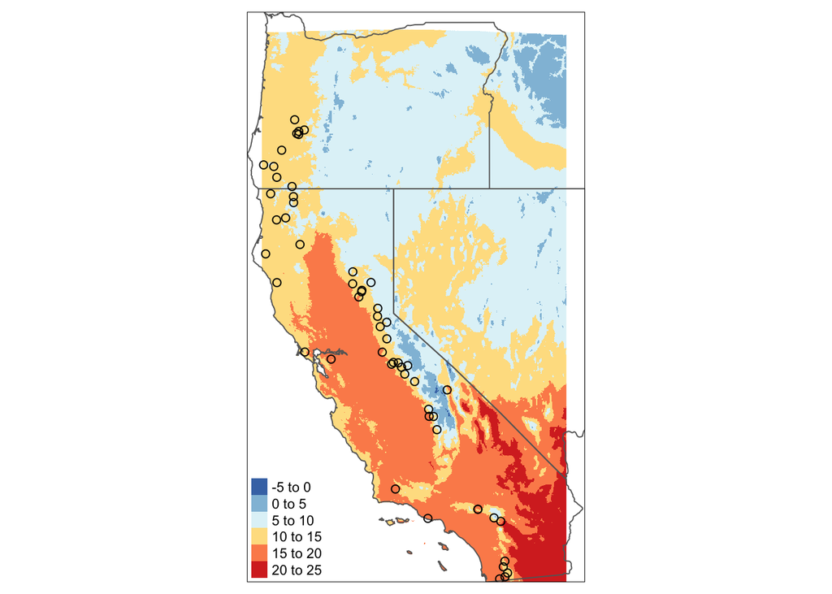

```r
# Plot MAT climate layer with populations and legend
pall_temp<-rev(brewer.pal(n=6, "RdYlBu")) #setup color gradient
tmap_mode("plot")
clim_MAT_pop <- tm_shape(MAT.clip, bbox=st_bbox(calo)) + #legal boundires
  tm_raster(palette=pall_temp)+
  tm_shape(calo)+
  tm_borders()+
  tm_shape(gen_pop_sf)+
  tm_dots(size=0.2,shape=1)+
  tm_layout(legend.position = c(0, 0),legend.title.size = 0.001)
clim_MAT_pop
```

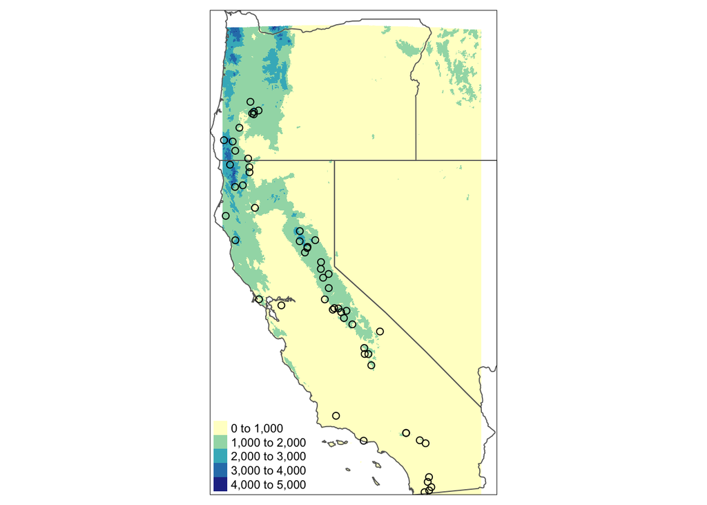

```r
# Plot MAP climate layer with populations and legend
pall_ppt<-brewer.pal(n=5, "YlGnBu") #setup color gradient
tmap_mode("plot")
clim_MAP_pop <- tm_shape(MAP.clip, bbox=st_bbox(calo)) + #legal boundires
  tm_raster(palette=pall_ppt)+
  tm_shape(calo)+
  tm_borders()+
  tm_shape(gen_pop_sf)+
  tm_dots(size=0.2,shape=1)+
  tm_layout(legend.position = c(0, 0),legend.title.size = 0.001)
clim_MAP_pop
```

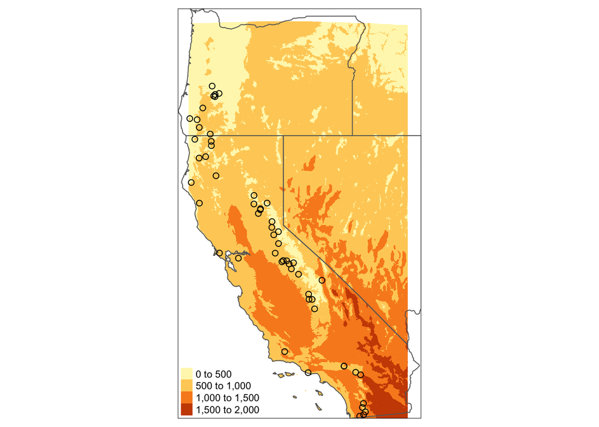

```r
# Plot CMD climate layer with populations and legend
tmap_mode("plot")
clim_CMD_pop <- tm_shape(CMD.clip, bbox=st_bbox(calo)) + #legal boundires
  tm_raster()+
  tm_shape(calo)+
  tm_borders()+
  tm_shape(gen_pop_sf)+
  tm_dots(size=0.2,shape=1)+
  tm_layout(legend.position = c(0, 0),legend.title.size = 0.001)
clim_CMD_pop
```

Notice how southern areas of the range of warmer and drier, while central and northern areas become cooler and wetter.

## 5. Use Mean Annual Temperature to inform assited migration

Now that we have everything loaded we will use these climate layers to find conditions on today’s climate that match future climate change conditions at a target site of conservaiton concern. Again we will use Site 8, Deep Creek as our target site. Fist we contain the climate layer to only display mean annual temperature values within +- 1 °C of the 2040 to 2070 climate change projection for Deep Creek (based the CMIP6 moderate cliamte change senario, SS245).

```r
#setup for ssp245 climate change projection for MAT
MAT.S17.ssp245<-MAT.clip #setup object
#Constrain by climate layer by 2040-2070 cliamte change projection +- 1 degree
MAT.S17.ssp245[MAT.clip<gcc.clim$MAT[8]-1] <-NA
MAT.S17.ssp245[MAT.clip>gcc.clim$MAT[8]+1] <-NA
```

Now we map only regious matching ssp245 MAT climate change projections for Deep Creek as pink layer.The 55 focal *M. cardinalis* populations are shown as open circles and Deep Creek is shown as a teal circle.

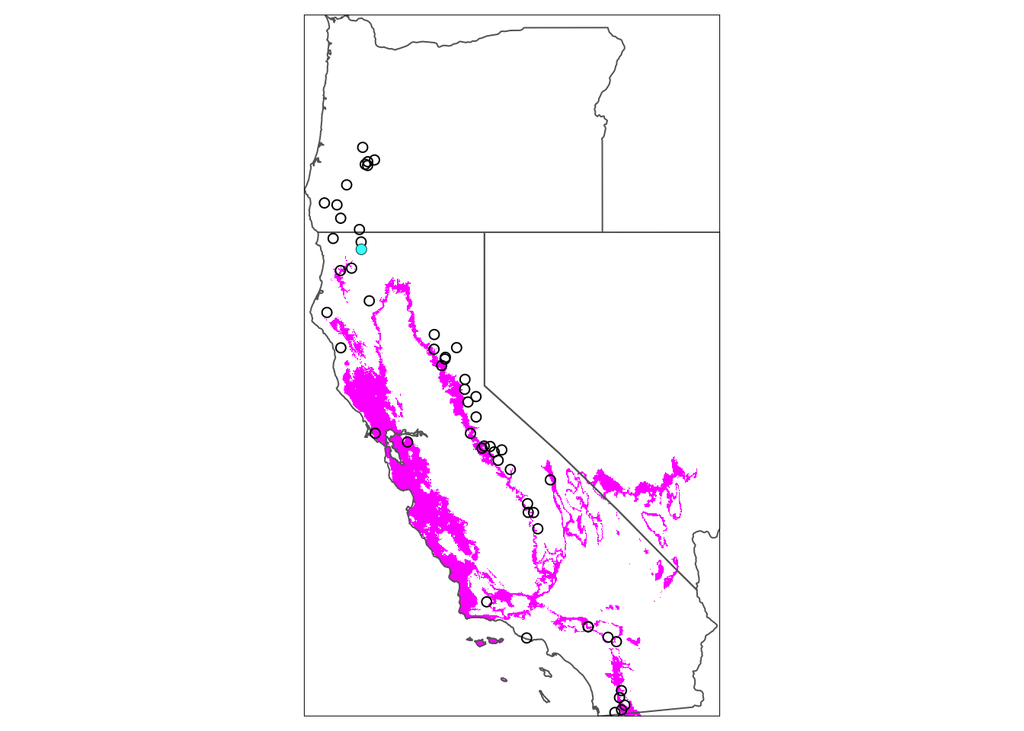

```r
tmap_mode("plot")
clim_MAT_245 <- tm_shape(MAT.S17.ssp245, bbox=st_bbox(calo)) + #legal boundires
  tm_raster(palette = "#FF00FF",legend.show = FALSE)+
  tm_shape(calo)+
  tm_borders()+
  tm_shape(gen_pop_sf)+
  tm_dots(size=0.2,shape=1)+
  tm_shape(p8_sf)+
  tm_dots(size=0.35,shape=20,col= "#33FFFF")+
  tm_layout(legend.position = c(0.29, 0.73),legend.title.size = 0.001)
clim_MAT_245
```

## 5. Use Mean Annual Precipitation to inform assited migration

We can apply this same approach now to mean annual precipitation. Again we constrain the cliamte layer, but this time by future MAP values of Deep Creek within +- 100 mm.

```r
#setup for ssp245 climate change projection for MAP
MAP.S17.ssp245<-MAP.clip #setup object
#Constrain by climate layer by 2040-2070 cliamte change projection +- 100 mm
MAP.S17.ssp245[MAP.clip<gcc.clim$MAP[8]-100] <-NA
MAP.S17.ssp245[MAP.clip>gcc.clim$MAP[8]+100] <-NA
```

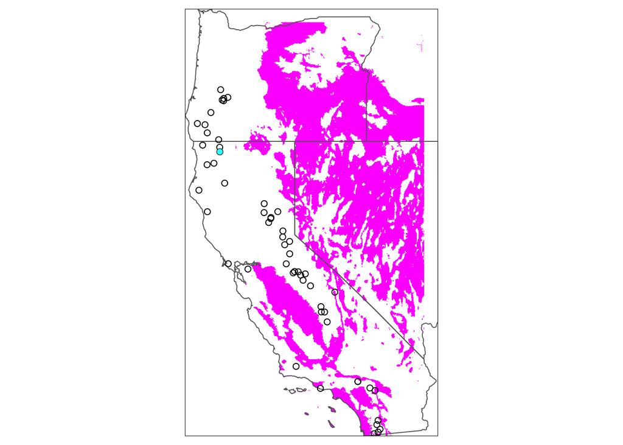

```r
tmap_mode("plot")
clim_MAP_245 <- tm_shape(MAP.S17.ssp245, bbox=st_bbox(calo)) + #legal boundires
  tm_raster(palette = "#FF00FF",legend.show = FALSE)+
  tm_shape(calo)+
  tm_borders()+
  tm_shape(gen_pop_sf)+
  tm_dots(size=0.2,shape=1)+
  tm_shape(p8_sf)+
  tm_dots(size=0.3,shape=20,col= "#33FFFF")+
  tm_layout(legend.position = c(0.1, 0.1),legend.title.size = 0.001)
clim_MAP_245
```

This time there are no populations in present day close to Deep Creek that experience the future climate change condition. The only populations that match future climate change projects is one central population and some southern populations. According to these analyses assisted migration would have to be carried from distant populations.

## 6. Use Climate Moisture Deficit to inform assited migration

Finally we can apply the same approach to Climate Moisture Deficit, a metric which takes into account both temperature and precipitation information. We constrain the climate layer, but this time by future CMD values of Deep Creek within +- 100 units.

```r
#setup for ssp245 climate change projection for CMD
CMD.S17.ssp245<-CMD.clip
#Constrain by climate layer by 2040-2070 climate change projection +- 100 units
CMD.S17.ssp245[CMD.clip<gcc.clim$CMD[8]-100] <-NA
CMD.S17.ssp245[CMD.clip>gcc.clim$CMD[8]+100] <-NA
```

We map only regions matching ssp245 CMD climate change projections for Deep Creek, plus the population localities.

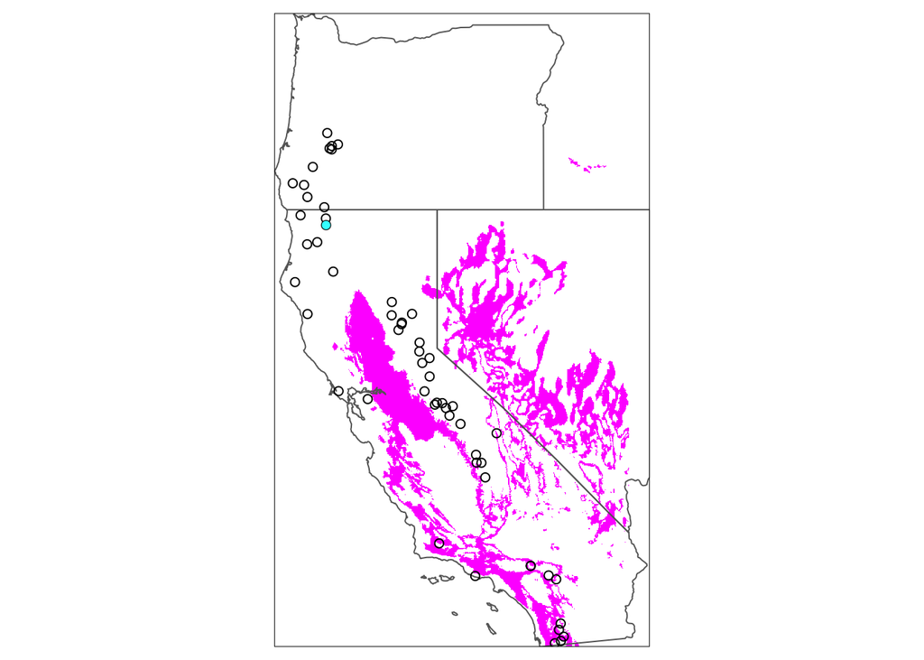

```r
tmap_mode("plot")
clim_CMD_245 <- tm_shape(CMD.S17.ssp245, bbox=st_bbox(calo)) + #legal boundires
  tm_raster(palette = "#FF00FF",legend.show = FALSE)+
  tm_shape(calo)+
  tm_borders()+
  tm_shape(gen_pop_sf)+
  tm_dots(size=0.2,shape=1)+
  tm_shape(p8_sf)+
  tm_dots(size=0.3,shape=20,col= "#33FFFF")+
  tm_layout(legend.position = c(0.29, 0.73),legend.title.size = 0.001)
clim_CMD_245
```

Again there are no populations in present day close to Deep Creek that experience the future climate change condition. Only one central and some southern populations have the appropriate present-day conditions. Without further genomic information, it will be difficult to know for sure if more northern population indeed do not have adaptive genetic variation. If it is not possible to sample from populations as far way, one option using this method would be to relax the climatic contraints to allow a broader range of conditions in the selected layer. For example, one could porduce a layer within +- 200 CMD units instead of 100. This should largely be informed by the biology of the system.

## 8. Conclusion

Overall we provide a visualization tool for using climate and population information to search for possible donor sites and develop conservation strategies. This would would function best in conjunction with genomic information to provide additional validation of adaptive potential of selected sites. However, given enough exploration of different filtering thresholds, this tool has wider potential usage across mutliple species because it does not requrie the resouces needed to carry out next generation sequencing and genomic data analysis.

In terms of the study system, this tools suggests that many locations on today’s climate match projected climate change conditions for temperature, but not for drought related variables. This provides evidence that adaption to drought may be a future concern for *M. cardinalis*.